# 04 - GP - Sine Functions

Kevin Feasel

2024-08-22

# Deriving A Sine Function

In this demo, we will use genetic programming to derive a sine function using basic mathematical tools. In the first part of this demo, we will have a limited set of tools and will see what a genetic program can generate. Then, in the second half, we will provide sufficient tools to solve the problem.

The library we are using is called `rgp` and is one of the genetic programming libraries for R. Unfortunately, it is in a defunct status and was archived in 2018. Sadly, there don’t appear to be any good successor libraries for genetic programming, so we’ll still use it.

```r
if(!require(emoa)) {
    install.packages("emoa")
    library(emoa)
}
if(!require(rgp)) {
    install.packages("rgp_0.4-1.tar.gz", repos = NULL, type="source")
    library(rgp)
}
```

```
*** RGP version 0.4-1 initialized successfully.
    Type 'help(package="rgp")' to bring up the RGP help pages,
    or type 'vignette("rgp_introduction")' to show RGP's package vignette.
    Type 'symbolicRegressionUi()' to bring up the symbolic regression UI if
    the optional package 'rgpui' is installed.
```

## Part One: Inadequate Tools

For this first part, we are going to try to derive a sine wave using three mathematical function: multiplication, addition, and subtraction. These three tools are not enough, on their own, to explain how a sine wave functions, but the genetic program will try its best regardless.

```r
function_set <- functionSet("+", "*", "-")
```

We will define everything in terms of one variable, which we will call `x`. You can name this variable anything you want, though.

```r
input_variable_set <- inputVariableSet("x")
```

We will use a factory method to generate constants. This will pull a pseudo-random number from a normal distribution.

```r
constant_factory_set <- constantFactorySet(function() { rnorm(1) })
```

We will define the interval for our calculation, spanning from -pi to pi. If we have several sine wave iterations, then the basic tools we have access to will behave even worse.

```r
function_interval <- seq(from = -pi, to = pi, by = 0.1)
```

Our fitness function describes how close the generated organism’s results are to a sine wave. We will use Root Mean Square Error to determine distance.

```r
fitness_function <- function(f) { rmse(f(function_interval), sin(function_interval)) }
```

Finally, we call the geneticProgramming function. This function takes the various objects we’ve created and builds programs. In this case, the program is a basic mathematical function. We will run for 20 seconds. Note that there are several stop conditions, including time-based, step-based, and fitness function result conditions.

```r
result <- geneticProgramming(
  functionSet = function_set,
  inputVariables = input_variable_set,
  constantSet = constant_factory_set,
  fitnessFunction = fitness_function,
  stopCondition = makeTimeStopCondition(20) #run for 20 seconds
)
```

```
STARTING genetic programming evolution run (Age/Fitness/Complexity Pareto GP search-heuristic) ...
evolution step 100, fitness evaluations: 4950, best fitness: 0.466563, time elapsed: 0.45 seconds
evolution step 200, fitness evaluations: 9950, best fitness: 0.446319, time elapsed: 0.66 seconds
evolution step 300, fitness evaluations: 14950, best fitness: 0.446319, time elapsed: 0.86 seconds
evolution step 400, fitness evaluations: 19950, best fitness: 0.446319, time elapsed: 1.05 seconds
evolution step 500, fitness evaluations: 24950, best fitness: 0.438795, time elapsed: 1.41 seconds
evolution step 600, fitness evaluations: 29950, best fitness: 0.351381, time elapsed: 1.73 seconds
evolution step 700, fitness evaluations: 34950, best fitness: 0.351381, time elapsed: 1.98 seconds
evolution step 800, fitness evaluations: 39950, best fitness: 0.351381, time elapsed: 2.19 seconds
evolution step 900, fitness evaluations: 44950, best fitness: 0.351381, time elapsed: 2.39 seconds
evolution step 1000, fitness evaluations: 49950, best fitness: 0.156434, time elapsed: 2.62 seconds
evolution step 1100, fitness evaluations: 54950, best fitness: 0.156434, time elapsed: 2.84 seconds
evolution step 1200, fitness evaluations: 59950, best fitness: 0.156434, time elapsed: 3.06 seconds
evolution step 1300, fitness evaluations: 64950, best fitness: 0.156434, time elapsed: 3.28 seconds
evolution step 1400, fitness evaluations: 69950, best fitness: 0.156434, time elapsed: 3.48 seconds
evolution step 1500, fitness evaluations: 74950, best fitness: 0.156434, time elapsed: 3.69 seconds
evolution step 1600, fitness evaluations: 79950, best fitness: 0.156434, time elapsed: 4 seconds
evolution step 1700, fitness evaluations: 84950, best fitness: 0.156434, time elapsed: 4.23 seconds
evolution step 1800, fitness evaluations: 89950, best fitness: 0.145234, time elapsed: 4.42 seconds
evolution step 1900, fitness evaluations: 94950, best fitness: 0.145234, time elapsed: 4.62 seconds
evolution step 2000, fitness evaluations: 99950, best fitness: 0.145234, time elapsed: 4.83 seconds
evolution step 2100, fitness evaluations: 104950, best fitness: 0.145234, time elapsed: 5.03 seconds
evolution step 2200, fitness evaluations: 109950, best fitness: 0.145234, time elapsed: 5.27 seconds
evolution step 2300, fitness evaluations: 114950, best fitness: 0.145234, time elapsed: 5.66 seconds
evolution step 2400, fitness evaluations: 119950, best fitness: 0.145234, time elapsed: 6.08 seconds
evolution step 2500, fitness evaluations: 124950, best fitness: 0.145234, time elapsed: 6.41 seconds
evolution step 2600, fitness evaluations: 129950, best fitness: 0.125628, time elapsed: 6.83 seconds
evolution step 2700, fitness evaluations: 134950, best fitness: 0.125628, time elapsed: 7.19 seconds
evolution step 2800, fitness evaluations: 139950, best fitness: 0.125628, time elapsed: 7.55 seconds
evolution step 2900, fitness evaluations: 144950, best fitness: 0.125628, time elapsed: 8 seconds
evolution step 3000, fitness evaluations: 149950, best fitness: 0.125628, time elapsed: 8.44 seconds
evolution step 3100, fitness evaluations: 154950, best fitness: 0.125628, time elapsed: 8.8 seconds
evolution step 3200, fitness evaluations: 159950, best fitness: 0.125628, time elapsed: 9.05 seconds
evolution step 3300, fitness evaluations: 164950, best fitness: 0.125628, time elapsed: 9.37 seconds
evolution step 3400, fitness evaluations: 169950, best fitness: 0.125628, time elapsed: 9.83 seconds
evolution step 3500, fitness evaluations: 174950, best fitness: 0.125628, time elapsed: 10.28 seconds
evolution step 3600, fitness evaluations: 179950, best fitness: 0.125129, time elapsed: 10.77 seconds
evolution step 3700, fitness evaluations: 184950, best fitness: 0.125129, time elapsed: 11.02 seconds
evolution step 3800, fitness evaluations: 189950, best fitness: 0.125043, time elapsed: 11.28 seconds
evolution step 3900, fitness evaluations: 194950, best fitness: 0.125043, time elapsed: 11.69 seconds
evolution step 4000, fitness evaluations: 199950, best fitness: 0.125043, time elapsed: 12.16 seconds
evolution step 4100, fitness evaluations: 204950, best fitness: 0.125043, time elapsed: 12.62 seconds
evolution step 4200, fitness evaluations: 209950, best fitness: 0.125043, time elapsed: 13.05 seconds
evolution step 4300, fitness evaluations: 214950, best fitness: 0.125043, time elapsed: 13.53 seconds
evolution step 4400, fitness evaluations: 219950, best fitness: 0.125043, time elapsed: 13.86 seconds
evolution step 4500, fitness evaluations: 224950, best fitness: 0.104130, time elapsed: 14.16 seconds
evolution step 4600, fitness evaluations: 229950, best fitness: 0.104130, time elapsed: 14.61 seconds
evolution step 4700, fitness evaluations: 234950, best fitness: 0.099700, time elapsed: 15.23 seconds
evolution step 4800, fitness evaluations: 239950, best fitness: 0.099700, time elapsed: 15.75 seconds
evolution step 4900, fitness evaluations: 244950, best fitness: 0.099700, time elapsed: 16.39 seconds
evolution step 5000, fitness evaluations: 249950, best fitness: 0.099700, time elapsed: 16.77 seconds
evolution step 5100, fitness evaluations: 254950, best fitness: 0.099700, time elapsed: 17.11 seconds
evolution step 5200, fitness evaluations: 259950, best fitness: 0.099700, time elapsed: 17.58 seconds
evolution step 5300, fitness evaluations: 264950, best fitness: 0.099700, time elapsed: 17.89 seconds
evolution step 5400, fitness evaluations: 269950, best fitness: 0.099700, time elapsed: 18.2 seconds
evolution step 5500, fitness evaluations: 274950, best fitness: 0.099700, time elapsed: 18.66 seconds
evolution step 5600, fitness evaluations: 279950, best fitness: 0.099700, time elapsed: 19.37 seconds
Genetic programming evolution run FINISHED after 5687 evolution steps, 284300 fitness evaluations and 20 seconds.
```

We now want to look at the best solution in the set. This is the member of the population with the **lowest** fitness value. Remember that our calculation is the RMSE, so a value of 0 would mean perfect alignment.

```r
best_solution <- result$population[[which.min(result$fitnessValues)]]
best_solution
```

```
function (x)
(x + x * x + 0.486623596054084 + (x - x - (x + x) + (x + (x -
    x - (x - x * x)) * -0.039330737386265))) * -0.108620094069081 *
    x + x
```

```r
min(result$fitnessValues)
```

```
[1] 0.09714842
```

We can check out how our function did by plotting our predicted functional results and then overlaying the sine wave. Note that best_solution actually is a function and not just a result.

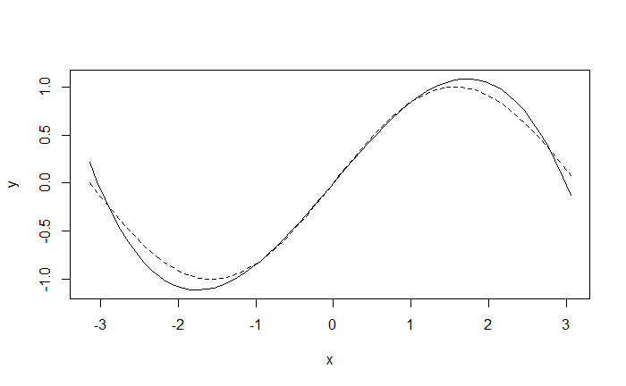

```r
plot(y = best_solution(function_interval), x = function_interval, type = "l", lty = 1, xlab = "x", ylab = "y")
lines(y = sin(function_interval), x = function_interval, lty = 2)
```

All in all, that’s not a terrible result, but it isn’t perfect. With better tools, we can get a much better result.

## Part 2: Adding Cosine

If we change the function set to include cosine, we will find much better results. We don’t need to change any other parts of the setup, though; they’re still fine.

```r
function_set <- functionSet("+", "*", "-", "cos")
```

Now we can run the genetic program again.

```r
result <- geneticProgramming(
  functionSet = function_set,
  inputVariables = input_variable_set,
  constantSet = constant_factory_set,
  fitnessFunction = fitness_function,
  stopCondition = makeTimeStopCondition(7) #run for 7 seconds
)
```

```
STARTING genetic programming evolution run (Age/Fitness/Complexity Pareto GP search-heuristic) ...
evolution step 100, fitness evaluations: 4950, best fitness: 0.015179, time elapsed: 0.52 seconds
evolution step 200, fitness evaluations: 9950, best fitness: 0.015179, time elapsed: 0.87 seconds
evolution step 300, fitness evaluations: 14950, best fitness: 0.014419, time elapsed: 1.3 seconds
evolution step 400, fitness evaluations: 19950, best fitness: 0.014419, time elapsed: 1.66 seconds
evolution step 500, fitness evaluations: 24950, best fitness: 0.014419, time elapsed: 2.06 seconds
evolution step 600, fitness evaluations: 29950, best fitness: 0.014419, time elapsed: 2.37 seconds
evolution step 700, fitness evaluations: 34950, best fitness: 0.008436, time elapsed: 2.61 seconds
evolution step 800, fitness evaluations: 39950, best fitness: 0.008436, time elapsed: 2.83 seconds
evolution step 900, fitness evaluations: 44950, best fitness: 0.008436, time elapsed: 3.03 seconds
evolution step 1000, fitness evaluations: 49950, best fitness: 0.008436, time elapsed: 3.23 seconds
evolution step 1100, fitness evaluations: 54950, best fitness: 0.008436, time elapsed: 3.44 seconds
evolution step 1200, fitness evaluations: 59950, best fitness: 0.008436, time elapsed: 3.66 seconds
evolution step 1300, fitness evaluations: 64950, best fitness: 0.008436, time elapsed: 3.87 seconds
evolution step 1400, fitness evaluations: 69950, best fitness: 0.008436, time elapsed: 4.11 seconds
evolution step 1500, fitness evaluations: 74950, best fitness: 0.001765, time elapsed: 4.34 seconds
evolution step 1600, fitness evaluations: 79950, best fitness: 0.001765, time elapsed: 4.56 seconds
evolution step 1700, fitness evaluations: 84950, best fitness: 0.001765, time elapsed: 4.8 seconds
evolution step 1800, fitness evaluations: 89950, best fitness: 0.001765, time elapsed: 5.02 seconds
evolution step 1900, fitness evaluations: 94950, best fitness: 0.001765, time elapsed: 5.36 seconds
evolution step 2000, fitness evaluations: 99950, best fitness: 0.001765, time elapsed: 5.75 seconds
evolution step 2100, fitness evaluations: 104950, best fitness: 0.001765, time elapsed: 6.19 seconds
evolution step 2200, fitness evaluations: 109950, best fitness: 0.001765, time elapsed: 6.62 seconds
Genetic programming evolution run FINISHED after 2274 evolution steps, 113650 fitness evaluations and 7 seconds.
```

We can check out the best solution again.

```r
best_solution <- result$population[[which.min(result$fitnessValues)]]
best_solution
```

```
function (x)
cos(x + (-0.581347694941419 - cos(0.127043246700049)))
```

```r
min(result$fitnessValues)
```

```
[1] 0.001764613
```

Note that there is a very minor difference, as the genetic program doesn’t have the construct of pi and so cannot calculate pi/2. If we did the calculation in radians, we likely could get a fitness value of 0. Still, that’s a lot closer!

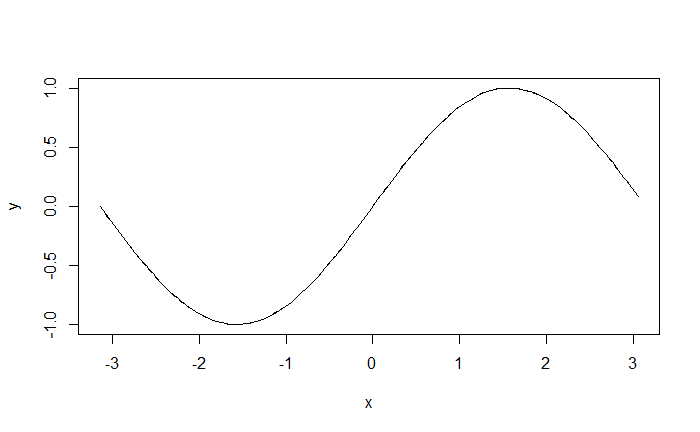

```r
plot(y = best_solution(function_interval), x = function_interval, type = "l", lty = 1, xlab = "x", ylab = "y")
lines(y = sin(function_interval), x = function_interval, lty = 2)
```

The lines are now so close that we can’t even see a difference.

## Part 3: Trigonometric Functions

We have some built-in function sets available to us, so we won’t need to specify each mathematical function independently. One example is trigonometric functions.

```r
function_set <- trigonometricFunctionSet
```

[output not shown]

We can run the genetic program again.

```r
result <- geneticProgramming(
  functionSet = function_set,
  inputVariables = input_variable_set,
  constantSet = constant_factory_set,
  fitnessFunction = fitness_function,
  stopCondition = makeTimeStopCondition(2) #run for 2 seconds
)
```

```
STARTING genetic programming evolution run (Age/Fitness/Complexity Pareto GP search-heuristic) ...
evolution step 100, fitness evaluations: 4950, best fitness: 0.111643, time elapsed: 0.44 seconds
evolution step 200, fitness evaluations: 9950, best fitness: 0.029833, time elapsed: 0.84 seconds
evolution step 300, fitness evaluations: 14950, best fitness: 0.029833, time elapsed: 1.11 seconds
evolution step 400, fitness evaluations: 19950, best fitness: 0.029833, time elapsed: 1.36 seconds
evolution step 500, fitness evaluations: 24950, best fitness: 0.011664, time elapsed: 1.61 seconds
evolution step 600, fitness evaluations: 29950, best fitness: 0.006842, time elapsed: 1.95 seconds
Genetic programming evolution run FINISHED after 607 evolution steps, 30300 fitness evaluations and 2 seconds.
```

We can check out the best solution again.

```r
best_solution <- result$population[[which.min(result$fitnessValues)]]
best_solution
```

```
function (x)
cos(cos(x - x) * 1.56113291973927 - x)
```

```r
min(result$fitnessValues)
```

```
[1] 0.006842137
```

From the rgp help file:

- `arithmeticFunctionSet` is an untyped function set containing the functions “+”, “-”, “*“, and”/“.
- `expLogFunctionSet` is an untyped function set containing the functions “sqrt”, “exp”, and “ln”.
- `trigonometricFunctionSet` is an untyped function set containing the functions “sin”, “cos”, and “tan”.
- `mathFunctionSet` is an untyped function set containing all of the above functions.

## Important Warning

Even with this successful notebook, I do **not** recommend using the `rgp` library at this point. Much of the functionality will cause modern versions of R to crash. In the next notebook, we’ll look at a (slightly) more modern library in `gramEvol`.